> **Tip**: Welcome to the Investigate a Dataset project! You will find tips in quoted sections like this to help organize your approach to your investigation. Before submitting your project, it will be a good idea to go back through your report and remove these sections to make the presentation of your work as tidy as possible. First things first, you might want to double-click this Markdown cell and change the title so that it reflects your dataset and investigation.

# Project: Investigate a Dataset (No Show Data Set)

- Introduction
- Data Wrangling
- Exploratory Data Analysis
- Conclusions

### Importing libraries to use in analyzing and visualizing data

```python
import numpy as np
import pandas as pd
import matplotlib.pyplot as plt
import seaborn as sns
%matplotlib inline
```

## Data Wrangling

> **Tip**: In this section of the report, you will load in the data, check for cleanliness, and then trim and clean your dataset for analysis. Make sure that you document your steps carefully and justify your cleaning decisions.

## Reading file

```python
df = pd.read_csv('KaggleV2-May-2016.csv')
df.head()
```

|  | PatientId | AppointmentID | Gender | ScheduledDay | AppointmentDay | Age | Neighbourhood | Scholarship | Hipertension | Diabetes | Alcoholism | Handcap | SMS_received | No-show |
| --- | --- | --- | --- | --- | --- | --- | --- | --- | --- | --- | --- | --- | --- | --- |
| 0 | 2.987250e+13 | 5642903 | F | 2016-04-29T18:38:08Z | 2016-04-29T00:00:00Z | 62 | JARDIM DA PENHA | 0 | 1 | 0 | 0 | 0 | 0 | No |
| 1 | 5.589978e+14 | 5642503 | M | 2016-04-29T16:08:27Z | 2016-04-29T00:00:00Z | 56 | JARDIM DA PENHA | 0 | 0 | 0 | 0 | 0 | 0 | No |
| 2 | 4.262962e+12 | 5642549 | F | 2016-04-29T16:19:04Z | 2016-04-29T00:00:00Z | 62 | MATA DA PRAIA | 0 | 0 | 0 | 0 | 0 | 0 | No |
| 3 | 8.679512e+11 | 5642828 | F | 2016-04-29T17:29:31Z | 2016-04-29T00:00:00Z | 8 | PONTAL DE CAMBURI | 0 | 0 | 0 | 0 | 0 | 0 | No |
| 4 | 8.841186e+12 | 5642494 | F | 2016-04-29T16:07:23Z | 2016-04-29T00:00:00Z | 56 | JARDIM DA PENHA | 0 | 1 | 1 | 0 | 0 | 0 | No |

### check wether we have duplicates or no

```python
sum(df.duplicated())
```

```
0
```

## Exploring data types and shapes in data sets

```python
df.info()
```

```
<class 'pandas.core.frame.DataFrame'>
RangeIndex: 110527 entries, 0 to 110526
Data columns (total 14 columns):
PatientId         110527 non-null float64
AppointmentID     110527 non-null int64
Gender            110527 non-null object
ScheduledDay      110527 non-null object
AppointmentDay    110527 non-null object
Age               110527 non-null int64
Neighbourhood     110527 non-null object
Scholarship       110527 non-null int64
Hipertension      110527 non-null int64
Diabetes          110527 non-null int64
Alcoholism        110527 non-null int64
Handcap           110527 non-null int64
SMS_received      110527 non-null int64
No-show           110527 non-null object
dtypes: float64(1), int64(8), object(5)
memory usage: 11.8+ MB
```

## Casting data types from objects to date time type

```python
df ['ScheduledDay'] = pd.to_datetime(df ['ScheduledDay'])
```

```python
df ['AppointmentDay'] = pd.to_datetime(df ['AppointmentDay'])
```

```python
df.shape
```

```
(110527, 14)
```

Let's rename the no-show cloumn to 'showed'

```python
df.rename(columns={'No-show':'showed'},inplace=True)
df.head(1)
```

|  | PatientId | AppointmentID | Gender | ScheduledDay | AppointmentDay | Age | Neighbourhood | Scholarship | Hipertension | Diabetes | Alcoholism | Handcap | SMS_received | showed |
| --- | --- | --- | --- | --- | --- | --- | --- | --- | --- | --- | --- | --- | --- | --- |
| 0 | 2.987250e+13 | 5642903 | F | 2016-04-29 18:38:08+00:00 | 2016-04-29 00:00:00+00:00 | 62 | JARDIM DA PENHA | 0 | 1 | 0 | 0 | 0 | 0 | No |

Let's change the values of Showed column No =1 and Yes =0

```python
df['showed']=df['showed'].apply(lambda x:1 if x=='No' else 0)
df.head(1)
```

|  | PatientId | AppointmentID | Gender | ScheduledDay | AppointmentDay | Age | Neighbourhood | Scholarship | Hipertension | Diabetes | Alcoholism | Handcap | SMS_received | showed |
| --- | --- | --- | --- | --- | --- | --- | --- | --- | --- | --- | --- | --- | --- | --- |
| 0 | 2.987250e+13 | 5642903 | F | 2016-04-29 18:38:08+00:00 | 2016-04-29 00:00:00+00:00 | 62 | JARDIM DA PENHA | 0 | 1 | 0 | 0 | 0 | 0 | 1 |

### counting how many diiferent Appointment id

```python
df['AppointmentID'] = df['AppointmentID'].apply(lambda x: str(int(x)));
```

```python
len(df['AppointmentID'].unique())
```

```
110527
```

### since we have 110527 Appointment id which is no duplicated appointment id so we can drop this column it won't affect our analysis

```python
df.drop(columns='AppointmentID',inplace=True)
df.head(1)
```

|  | PatientId | Gender | ScheduledDay | AppointmentDay | Age | Neighbourhood | Scholarship | Hipertension | Diabetes | Alcoholism | Handcap | SMS_received | showed |
| --- | --- | --- | --- | --- | --- | --- | --- | --- | --- | --- | --- | --- | --- |
| 0 | 2.987250e+13 | F | 2016-04-29 18:38:08+00:00 | 2016-04-29 00:00:00+00:00 | 62 | JARDIM DA PENHA | 0 | 1 | 0 | 0 | 0 | 0 | 1 |

```python
df.columns
```

```
Index(['PatientId', 'Gender', 'ScheduledDay', 'AppointmentDay', 'Age',
       'Neighbourhood', 'Scholarship', 'Hipertension', 'Diabetes',
       'Alcoholism', 'Handcap', 'SMS_received', 'showed'],
      dtype='object')
```

```python
df.info()
```

```
<class 'pandas.core.frame.DataFrame'>
RangeIndex: 110527 entries, 0 to 110526
Data columns (total 13 columns):
PatientId         110527 non-null float64
Gender            110527 non-null object
ScheduledDay      110527 non-null datetime64[ns, UTC]
AppointmentDay    110527 non-null datetime64[ns, UTC]
Age               110527 non-null int64
Neighbourhood     110527 non-null object
Scholarship       110527 non-null int64
Hipertension      110527 non-null int64
Diabetes          110527 non-null int64
Alcoholism        110527 non-null int64
Handcap           110527 non-null int64
SMS_received      110527 non-null int64
showed            110527 non-null int64
dtypes: datetime64[ns, UTC](2), float64(1), int64(8), object(2)
memory usage: 11.0+ MB
```

## droping the values that have age less than zero which is imposible to have

```python
df = df[(df.Age>=0)]
```

```python
df.describe()
```

|  | PatientId | Age | Scholarship | Hipertension | Diabetes | Alcoholism | Handcap | SMS_received | showed |
| --- | --- | --- | --- | --- | --- | --- | --- | --- | --- |
| count | 1.105260e+05 | 110526.000000 | 110526.000000 | 110526.000000 | 110526.000000 | 110526.000000 | 110526.000000 | 110526.000000 | 110526.000000 |
| mean | 1.474934e+14 | 37.089219 | 0.098266 | 0.197248 | 0.071865 | 0.030400 | 0.022248 | 0.321029 | 0.798066 |
| std | 2.560943e+14 | 23.110026 | 0.297676 | 0.397923 | 0.258266 | 0.171686 | 0.161543 | 0.466874 | 0.401445 |
| min | 3.921784e+04 | 0.000000 | 0.000000 | 0.000000 | 0.000000 | 0.000000 | 0.000000 | 0.000000 | 0.000000 |
| 25% | 4.172536e+12 | 18.000000 | 0.000000 | 0.000000 | 0.000000 | 0.000000 | 0.000000 | 0.000000 | 1.000000 |
| 50% | 3.173184e+13 | 37.000000 | 0.000000 | 0.000000 | 0.000000 | 0.000000 | 0.000000 | 0.000000 | 1.000000 |
| 75% | 9.438963e+13 | 55.000000 | 0.000000 | 0.000000 | 0.000000 | 0.000000 | 0.000000 | 1.000000 | 1.000000 |
| max | 9.999816e+14 | 115.000000 | 1.000000 | 1.000000 | 1.000000 | 1.000000 | 4.000000 | 1.000000 | 1.000000 |

## dropping any up normal values in handcap which the value only are 0 and 1

```python
df['Handcap'] = np.where(df['Handcap']>0, 1, 0)
```

```python
df.describe()
```

|  | PatientId | Age | Scholarship | Hipertension | Diabetes | Alcoholism | Handcap | SMS_received | showed |
| --- | --- | --- | --- | --- | --- | --- | --- | --- | --- |
| count | 1.105260e+05 | 110526.000000 | 110526.000000 | 110526.000000 | 110526.000000 | 110526.000000 | 110526.000000 | 110526.000000 | 110526.000000 |
| mean | 1.474934e+14 | 37.089219 | 0.098266 | 0.197248 | 0.071865 | 0.030400 | 0.020276 | 0.321029 | 0.798066 |
| std | 2.560943e+14 | 23.110026 | 0.297676 | 0.397923 | 0.258266 | 0.171686 | 0.140943 | 0.466874 | 0.401445 |
| min | 3.921784e+04 | 0.000000 | 0.000000 | 0.000000 | 0.000000 | 0.000000 | 0.000000 | 0.000000 | 0.000000 |
| 25% | 4.172536e+12 | 18.000000 | 0.000000 | 0.000000 | 0.000000 | 0.000000 | 0.000000 | 0.000000 | 1.000000 |
| 50% | 3.173184e+13 | 37.000000 | 0.000000 | 0.000000 | 0.000000 | 0.000000 | 0.000000 | 0.000000 | 1.000000 |
| 75% | 9.438963e+13 | 55.000000 | 0.000000 | 0.000000 | 0.000000 | 0.000000 | 0.000000 | 1.000000 | 1.000000 |
| max | 9.999816e+14 | 115.000000 | 1.000000 | 1.000000 | 1.000000 | 1.000000 | 1.000000 | 1.000000 | 1.000000 |

```python
df.head()
```

|  | PatientId | Gender | ScheduledDay | AppointmentDay | Age | Neighbourhood | Scholarship | Hipertension | Diabetes | Alcoholism | Handcap | SMS_received | showed |
| --- | --- | --- | --- | --- | --- | --- | --- | --- | --- | --- | --- | --- | --- |
| 0 | 2.987250e+13 | F | 2016-04-29 18:38:08+00:00 | 2016-04-29 00:00:00+00:00 | 62 | JARDIM DA PENHA | 0 | 1 | 0 | 0 | 0 | 0 | 1 |
| 1 | 5.589978e+14 | M | 2016-04-29 16:08:27+00:00 | 2016-04-29 00:00:00+00:00 | 56 | JARDIM DA PENHA | 0 | 0 | 0 | 0 | 0 | 0 | 1 |
| 2 | 4.262962e+12 | F | 2016-04-29 16:19:04+00:00 | 2016-04-29 00:00:00+00:00 | 62 | MATA DA PRAIA | 0 | 0 | 0 | 0 | 0 | 0 | 1 |
| 3 | 8.679512e+11 | F | 2016-04-29 17:29:31+00:00 | 2016-04-29 00:00:00+00:00 | 8 | PONTAL DE CAMBURI | 0 | 0 | 0 | 0 | 0 | 0 | 1 |
| 4 | 8.841186e+12 | F | 2016-04-29 16:07:23+00:00 | 2016-04-29 00:00:00+00:00 | 56 | JARDIM DA PENHA | 0 | 1 | 1 | 0 | 0 | 0 | 1 |

#### People whom showed up and people didn't

```python
print("{} People showed up of approximately {:0.1f}%".format(df['showed'].sum(),df['showed'].mean()*100))
print("{} People didn't showed up of approximately {:0.1f}%".format(df.shape[0]-df['showed'].sum(),100-(df['showed'].mean()*100)))
```

```
88207 People showed up of approximately 79.8%
22319 People didn't showed up of approximately 20.2%
```

### some stats for the dataframe

```python
df.describe()
```

|  | PatientId | Age | Scholarship | Hipertension | Diabetes | Alcoholism | Handcap | SMS_received | showed |
| --- | --- | --- | --- | --- | --- | --- | --- | --- | --- |
| count | 1.105260e+05 | 110526.000000 | 110526.000000 | 110526.000000 | 110526.000000 | 110526.000000 | 110526.000000 | 110526.000000 | 110526.000000 |
| mean | 1.474934e+14 | 37.089219 | 0.098266 | 0.197248 | 0.071865 | 0.030400 | 0.020276 | 0.321029 | 0.798066 |
| std | 2.560943e+14 | 23.110026 | 0.297676 | 0.397923 | 0.258266 | 0.171686 | 0.140943 | 0.466874 | 0.401445 |
| min | 3.921784e+04 | 0.000000 | 0.000000 | 0.000000 | 0.000000 | 0.000000 | 0.000000 | 0.000000 | 0.000000 |
| 25% | 4.172536e+12 | 18.000000 | 0.000000 | 0.000000 | 0.000000 | 0.000000 | 0.000000 | 0.000000 | 1.000000 |
| 50% | 3.173184e+13 | 37.000000 | 0.000000 | 0.000000 | 0.000000 | 0.000000 | 0.000000 | 0.000000 | 1.000000 |
| 75% | 9.438963e+13 | 55.000000 | 0.000000 | 0.000000 | 0.000000 | 0.000000 | 0.000000 | 1.000000 | 1.000000 |
| max | 9.999816e+14 | 115.000000 | 1.000000 | 1.000000 | 1.000000 | 1.000000 | 1.000000 | 1.000000 | 1.000000 |

Let's split the data for people who showed up and people who didn't

```python
showed=df['showed']==1
df[showed].head()
```

|  | PatientId | Gender | ScheduledDay | AppointmentDay | Age | Neighbourhood | Scholarship | Hipertension | Diabetes | Alcoholism | Handcap | SMS_received | showed |
| --- | --- | --- | --- | --- | --- | --- | --- | --- | --- | --- | --- | --- | --- |
| 0 | 2.987250e+13 | F | 2016-04-29 18:38:08+00:00 | 2016-04-29 00:00:00+00:00 | 62 | JARDIM DA PENHA | 0 | 1 | 0 | 0 | 0 | 0 | 1 |
| 1 | 5.589978e+14 | M | 2016-04-29 16:08:27+00:00 | 2016-04-29 00:00:00+00:00 | 56 | JARDIM DA PENHA | 0 | 0 | 0 | 0 | 0 | 0 | 1 |
| 2 | 4.262962e+12 | F | 2016-04-29 16:19:04+00:00 | 2016-04-29 00:00:00+00:00 | 62 | MATA DA PRAIA | 0 | 0 | 0 | 0 | 0 | 0 | 1 |
| 3 | 8.679512e+11 | F | 2016-04-29 17:29:31+00:00 | 2016-04-29 00:00:00+00:00 | 8 | PONTAL DE CAMBURI | 0 | 0 | 0 | 0 | 0 | 0 | 1 |
| 4 | 8.841186e+12 | F | 2016-04-29 16:07:23+00:00 | 2016-04-29 00:00:00+00:00 | 56 | JARDIM DA PENHA | 0 | 1 | 1 | 0 | 0 | 0 | 1 |

Some stats for people who showed up

```python
df[showed].describe()
```

|  | PatientId | Age | Scholarship | Hipertension | Diabetes | Alcoholism | Handcap | SMS_received | showed |
| --- | --- | --- | --- | --- | --- | --- | --- | --- | --- |
| count | 8.820700e+04 | 88207.000000 | 88207.000000 | 88207.000000 | 88207.000000 | 88207.000000 | 88207.000000 | 88207.000000 | 88207.0 |
| mean | 1.476809e+14 | 37.790504 | 0.093904 | 0.204394 | 0.073838 | 0.030417 | 0.020792 | 0.291337 | 1.0 |
| std | 2.563739e+14 | 23.338645 | 0.291697 | 0.403261 | 0.261508 | 0.171733 | 0.142688 | 0.454381 | 0.0 |
| min | 3.921784e+04 | 0.000000 | 0.000000 | 0.000000 | 0.000000 | 0.000000 | 0.000000 | 0.000000 | 1.0 |
| 25% | 4.168386e+12 | 18.000000 | 0.000000 | 0.000000 | 0.000000 | 0.000000 | 0.000000 | 0.000000 | 1.0 |
| 50% | 3.176138e+13 | 38.000000 | 0.000000 | 0.000000 | 0.000000 | 0.000000 | 0.000000 | 0.000000 | 1.0 |
| 75% | 9.433684e+13 | 56.000000 | 0.000000 | 0.000000 | 0.000000 | 0.000000 | 0.000000 | 1.000000 | 1.0 |
| max | 9.999816e+14 | 115.000000 | 1.000000 | 1.000000 | 1.000000 | 1.000000 | 1.000000 | 1.000000 | 1.0 |

1-average of people who showed up is 37

2- 9% of them had a scholarship

3- and 20% where hypertensed

4- 7% where diabetes

5- 3% where alcohlolic

7- 29% recieved the sms

Data set for people who didn't show up

```python
n_showed=df['showed']==0
df[n_showed].head()
```

|  | PatientId | Gender | ScheduledDay | AppointmentDay | Age | Neighbourhood | Scholarship | Hipertension | Diabetes | Alcoholism | Handcap | SMS_received | showed |
| --- | --- | --- | --- | --- | --- | --- | --- | --- | --- | --- | --- | --- | --- |
| 6 | 7.336882e+14 | F | 2016-04-27 15:05:12+00:00 | 2016-04-29 00:00:00+00:00 | 23 | GOIABEIRAS | 0 | 0 | 0 | 0 | 0 | 0 | 0 |
| 7 | 3.449833e+12 | F | 2016-04-27 15:39:58+00:00 | 2016-04-29 00:00:00+00:00 | 39 | GOIABEIRAS | 0 | 0 | 0 | 0 | 0 | 0 | 0 |
| 11 | 7.542951e+12 | M | 2016-04-26 08:44:12+00:00 | 2016-04-29 00:00:00+00:00 | 29 | NOVA PALESTINA | 0 | 0 | 0 | 0 | 0 | 1 | 0 |
| 17 | 1.479497e+13 | F | 2016-04-28 09:28:57+00:00 | 2016-04-29 00:00:00+00:00 | 40 | CONQUISTA | 1 | 0 | 0 | 0 | 0 | 0 | 0 |
| 20 | 6.222575e+14 | F | 2016-04-27 07:51:14+00:00 | 2016-04-29 00:00:00+00:00 | 30 | NOVA PALESTINA | 0 | 0 | 0 | 0 | 0 | 0 | 0 |

```python
df[n_showed].describe()
```

|  | PatientId | Age | Scholarship | Hipertension | Diabetes | Alcoholism | Handcap | SMS_received | showed |
| --- | --- | --- | --- | --- | --- | --- | --- | --- | --- |
| count | 2.231900e+04 | 22319.000000 | 22319.000000 | 22319.000000 | 22319.000000 | 22319.000000 | 22319.000000 | 22319.000000 | 22319.0 |
| mean | 1.467523e+14 | 34.317667 | 0.115507 | 0.169004 | 0.064071 | 0.030333 | 0.018236 | 0.438371 | 0.0 |
| std | 2.549905e+14 | 21.965941 | 0.319640 | 0.374764 | 0.244885 | 0.171505 | 0.133805 | 0.496198 | 0.0 |
| min | 5.628261e+06 | 0.000000 | 0.000000 | 0.000000 | 0.000000 | 0.000000 | 0.000000 | 0.000000 | 0.0 |
| 25% | 4.176779e+12 | 16.000000 | 0.000000 | 0.000000 | 0.000000 | 0.000000 | 0.000000 | 0.000000 | 0.0 |
| 50% | 3.156794e+13 | 33.000000 | 0.000000 | 0.000000 | 0.000000 | 0.000000 | 0.000000 | 0.000000 | 0.0 |
| 75% | 9.454270e+13 | 51.000000 | 0.000000 | 0.000000 | 0.000000 | 0.000000 | 0.000000 | 1.000000 | 0.0 |
| max | 9.996585e+14 | 115.000000 | 1.000000 | 1.000000 | 1.000000 | 1.000000 | 1.000000 | 1.000000 | 0.0 |

Some outputs

1- average age of people who didn't show up is 34

2- average only 11% of them had a scholarship

3- average of 16% of people who didn't show up where hypertensed

4- average of 6% where diabetes

5- average of 3% where alcohlic

6- average of 2% where handcap

7- average of 43% recieved there sms and didn't show up

## counting each gender value

```python
df.Gender.value_counts()
```

```
F    71839
M    38687
Name: Gender, dtype: int64
```

### Does any gender shows up more than the other gender ?

The females number nearly doubles the Males , so let's look to the percentage who showed up

```python
print("{:.1f}% of females showed Up".format(df[df['Gender']=='F']['showed'].mean()*100))
print("{:.1f}% of males showed Up".format(df[df['Gender']=='M']['showed'].mean()*100))
```

```
79.7% of females showed Up
80.0% of males showed Up
```

They are nearly equal

## Let's make another variable that is the difference between the appointment day and the scheduled day, it make make a difference in how we are seeing the data

Since we need only the date not the hourly stamp we should truncate to the date

```python
df['date_dif']=(((df['AppointmentDay'].dt.date)-(df['ScheduledDay'].dt.date))/np.timedelta64(1, 'D')).astype(int)
df.head(1)
```

|  | PatientId | Gender | ScheduledDay | AppointmentDay | Age | Neighbourhood | Scholarship | Hipertension | Diabetes | Alcoholism | Handcap | SMS_received | showed | date_dif |
| --- | --- | --- | --- | --- | --- | --- | --- | --- | --- | --- | --- | --- | --- | --- |
| 0 | 2.987250e+13 | F | 2016-04-29 18:38:08+00:00 | 2016-04-29 00:00:00+00:00 | 62 | JARDIM DA PENHA | 0 | 1 | 0 | 0 | 0 | 0 | 1 | 0 |

Since we will be using this in analysis let's see the distribution of the date_diff

```python
df['date_dif'].describe()
```

```
count    110526.000000
mean         10.183794
std          15.255034
min          -6.000000
25%           0.000000
50%           4.000000
75%          15.000000
max         179.000000
Name: date_dif, dtype: float64
```

Here we find something important, it's not rational to have a difference between the two dates in negative, since the appointment date must be bigger than the scheduled date! so we here should drop rows of date_diff < 0 ! Good relization i guess

```python
df.shape
```

```
(110526, 14)
```

```python
df=df[df['date_dif']>=0]
df.shape
```

```
(110521, 14)
```

```python
df['date_dif'].describe()
```

```
count    110521.000000
mean         10.184345
std          15.255153
min           0.000000
25%           0.000000
50%           4.000000
75%          15.000000
max         179.000000
Name: date_dif, dtype: float64
```

```python
df.query("Gender=='F'")['WaitingDays'].median() , df.query("Gender=='M'")['WaitingDays'].median()
```

[output not shown]

Now let's make a column of the hour of the scheduled day

```python
df['sched_h']=df['ScheduledDay'].dt.hour
df.head(1)
```

|  | PatientId | Gender | ScheduledDay | AppointmentDay | Age | Neighbourhood | Scholarship | Hipertension | Diabetes | Alcoholism | Handcap | SMS_received | showed | date_dif | sched_h |
| --- | --- | --- | --- | --- | --- | --- | --- | --- | --- | --- | --- | --- | --- | --- | --- |
| 0 | 2.987250e+13 | F | 2016-04-29 18:38:08+00:00 | 2016-04-29 00:00:00+00:00 | 62 | JARDIM DA PENHA | 0 | 1 | 0 | 0 | 0 | 0 | 1 | 0 | 18 |

Now we can drop both columns of scheduled day and appointment day

```python
df.drop(columns=['ScheduledDay','AppointmentDay'],inplace=True)
df.head()
```

|  | PatientId | Gender | Age | Neighbourhood | Scholarship | Hipertension | Diabetes | Alcoholism | Handcap | SMS_received | showed | date_dif | sched_h |
| --- | --- | --- | --- | --- | --- | --- | --- | --- | --- | --- | --- | --- | --- |
| 0 | 2.987250e+13 | F | 62 | JARDIM DA PENHA | 0 | 1 | 0 | 0 | 0 | 0 | 1 | 0 | 18 |
| 1 | 5.589978e+14 | M | 56 | JARDIM DA PENHA | 0 | 0 | 0 | 0 | 0 | 0 | 1 | 0 | 16 |
| 2 | 4.262962e+12 | F | 62 | MATA DA PRAIA | 0 | 0 | 0 | 0 | 0 | 0 | 1 | 0 | 16 |
| 3 | 8.679512e+11 | F | 8 | PONTAL DE CAMBURI | 0 | 0 | 0 | 0 | 0 | 0 | 1 | 0 | 17 |
| 4 | 8.841186e+12 | F | 56 | JARDIM DA PENHA | 0 | 1 | 1 | 0 | 0 | 0 | 1 | 0 | 16 |

### Let's explore if there was a correlation between variables or no

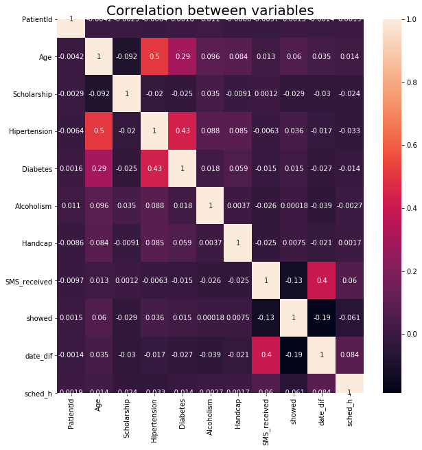

```python
plt.figure(figsize=(10,10))
ax=sns.heatmap(df.corr(),annot=True);
ax.axes.set_title("Correlation between variables",fontsize=20);
```

### Printing all Neighbourhoods

```python
neighborhood = df.Neighbourhood.unique()
neighborhood.sort()  #Sorting the names in alphabetical order
neighborhood
```

```
array(['AEROPORTO', 'ANDORINHAS', 'ANTÔNIO HONÓRIO',
       'ARIOVALDO FAVALESSA', 'BARRO VERMELHO', 'BELA VISTA',
       'BENTO FERREIRA', 'BOA VISTA', 'BONFIM', 'CARATOÍRA', 'CENTRO',
       'COMDUSA', 'CONQUISTA', 'CONSOLAÇÃO', 'CRUZAMENTO', 'DA PENHA',
       'DE LOURDES', 'DO CABRAL', 'DO MOSCOSO', 'DO QUADRO',
       'ENSEADA DO SUÁ', 'ESTRELINHA', 'FONTE GRANDE', 'FORTE SÃO JOÃO',
       'FRADINHOS', 'GOIABEIRAS', 'GRANDE VITÓRIA', 'GURIGICA', 'HORTO',
       'ILHA DAS CAIEIRAS', 'ILHA DE SANTA MARIA', 'ILHA DO BOI',
       'ILHA DO FRADE', 'ILHA DO PRÍNCIPE', 'ILHAS OCEÂNICAS DE TRINDADE',
       'INHANGUETÁ', 'ITARARÉ', 'JABOUR', 'JARDIM CAMBURI',
       'JARDIM DA PENHA', 'JESUS DE NAZARETH', 'JOANA D´ARC',
       'JUCUTUQUARA', 'MARIA ORTIZ', 'MARUÍPE', 'MATA DA PRAIA',
       'MONTE BELO', 'MORADA DE CAMBURI', 'MÁRIO CYPRESTE', 'NAZARETH',
       'NOVA PALESTINA', 'PARQUE INDUSTRIAL', 'PARQUE MOSCOSO', 'PIEDADE',
       'PONTAL DE CAMBURI', 'PRAIA DO CANTO', 'PRAIA DO SUÁ', 'REDENÇÃO',
       'REPÚBLICA', 'RESISTÊNCIA', 'ROMÃO', 'SANTA CECÍLIA',
       'SANTA CLARA', 'SANTA HELENA', 'SANTA LUÍZA', 'SANTA LÚCIA',
       'SANTA MARTHA', 'SANTA TEREZA', 'SANTO ANDRÉ', 'SANTO ANTÔNIO',
       'SANTOS DUMONT', 'SANTOS REIS', 'SEGURANÇA DO LAR', 'SOLON BORGES',
       'SÃO BENEDITO', 'SÃO CRISTÓVÃO', 'SÃO JOSÉ', 'SÃO PEDRO',
       'TABUAZEIRO', 'UNIVERSITÁRIO', 'VILA RUBIM'], dtype=object)
```

### counting how many different Neighbourhood

```python
len(df['Neighbourhood'].unique())
```

```
81
```

### visualizing each Neighbourhood and how many people comes from it

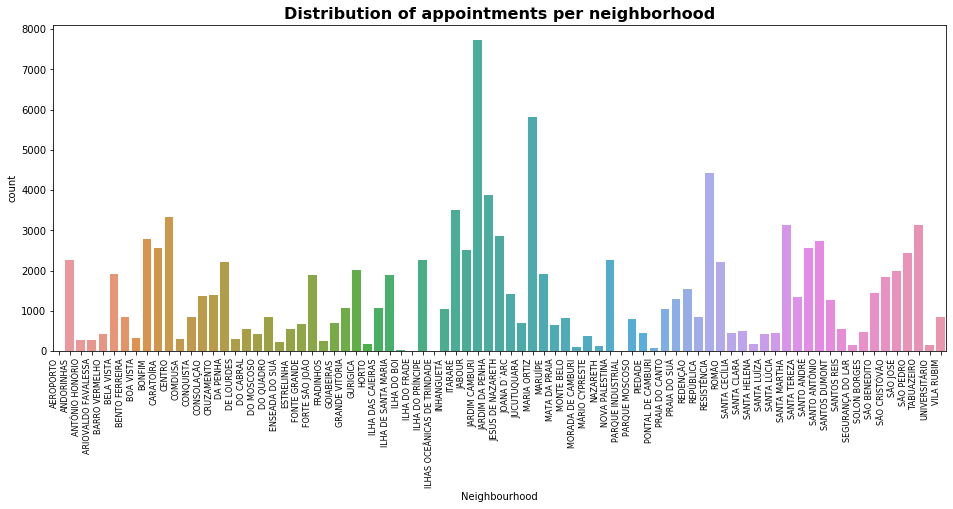

```python
plt.figure(figsize=(16,6))
ax = sns.countplot(x='Neighbourhood', data=df, order=neighborhood)
ax.set_xticklabels(ax.get_xticklabels(), rotation=90, ha="right", fontsize=8)
plt.title('Distribution of appointments per neighborhood', fontsize=16, fontweight='bold')
plt.show()
```

### Visualizing all data frame to get to know the trends

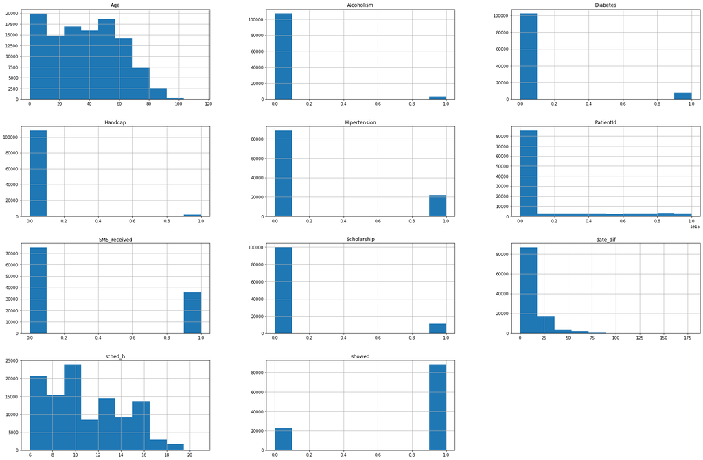

```python
df.hist(figsize=(30,20));
```

### counting the values that showed up and that didn't

```python
df['showed'].value_counts()
```

```
1    88207
0    22314
Name: showed, dtype: int64
```

### Visualizing the features to extract some patterns

#### Does age make any difference ?

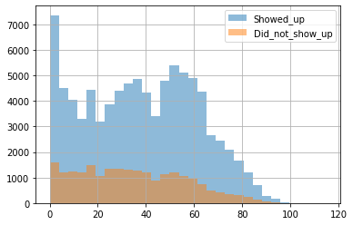

```python
df.Age[showed==1].hist(alpha=0.5,bins=30 ,label='Showed_up');
df.Age[showed==0].hist(alpha=0.5,bins=30 ,label='Did_not_show_up');
plt.legend();
```

#### Does gender make any difference ?

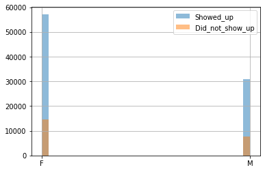

```python
df.Gender[showed==1].hist(alpha=0.5,bins=30 ,label='Showed_up');
df.Gender[showed==0].hist(alpha=0.5,bins=30 ,label='Did_not_show_up');
plt.legend();
```

#### Does recieving an sms make any difference ?

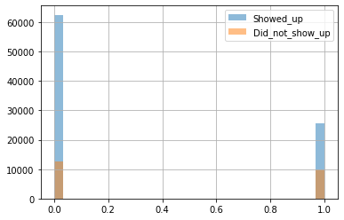

```python
df.SMS_received[showed==1].hist(alpha=0.5,bins=30 ,label='Showed_up');
df.SMS_received[showed==0].hist(alpha=0.5,bins=30 ,label='Did_not_show_up');
plt.legend()
```

#### Does being a hancape make any difference ?

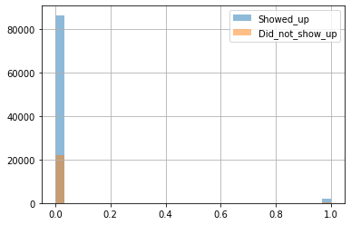

```python
df.Handcap[showed==1].hist(alpha=0.5,bins=30 ,label='Showed_up');
df.Handcap[showed==0].hist(alpha=0.5,bins=30 ,label='Did_not_show_up');
plt.legend()
```

#### Does being Diabetic make any difference ?

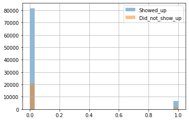

```python
df.Diabetes[showed==1].hist(alpha=0.5,bins=30 ,label='Showed_up');
df.Diabetes[showed==0].hist(alpha=0.5,bins=30 ,label='Did_not_show_up');
plt.legend()
```

#### Does drinking alcohlic drinks make any difference ?

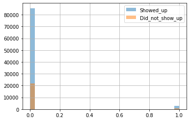

```python
df.Alcoholism[showed==1].hist(alpha=0.5,bins=30 ,label='Showed_up');
df.Alcoholism[showed==0].hist(alpha=0.5,bins=30 ,label='Did_not_show_up');
plt.legend()
```

#### Does having hypertension make any difference ?

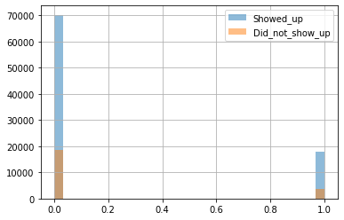

```python
df.Hipertension[showed==1].hist(alpha=0.5,bins=30 ,label='Showed_up');
df.Hipertension[showed==0].hist(alpha=0.5,bins=30 ,label='Did_not_show_up');
plt.legend()
```

#### Does the Neighbourhood make any difference ?

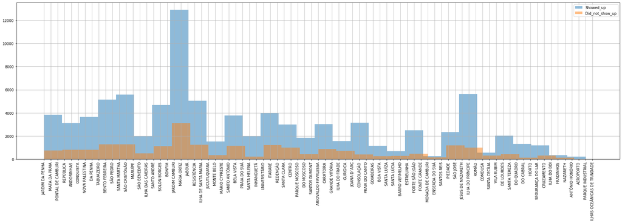

```python
df.Neighbourhood[showed==1].hist(alpha=0.5,bins=30 ,label='Showed_up',figsize=(30,8),xrot=90);
df.Neighbourhood[showed==0].hist(alpha=0.5,bins=30 ,label='Did_not_show_up',figsize=(30,8),xrot=90);

plt.legend()
```

#### Does the waiting days make any difference ?

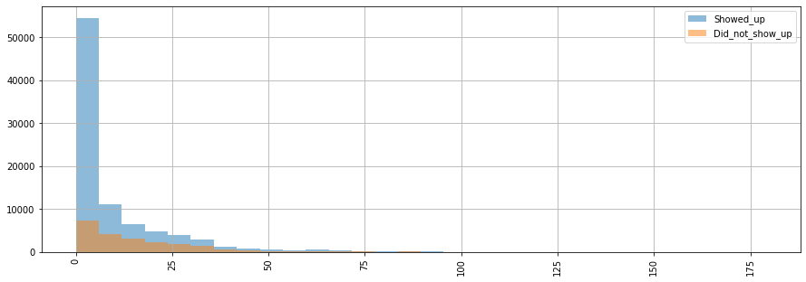

```python
df.date_dif[showed==1].hist(alpha=0.5,bins=30 ,label='Showed_up',xrot=90,figsize=(15,5));
df.date_dif[showed==0].hist(alpha=0.5,bins=30 ,label='Did_not_show_up',xrot=90,figsize=(15,5));

plt.legend();
```

#### Does the Scholarship make any difference ?

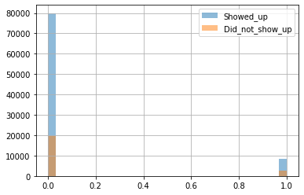

```python
df.Scholarship[showed==1].hist(alpha=0.5,bins=30 ,label='Showed_up');
df.Scholarship[showed==0].hist(alpha=0.5,bins=30 ,label='Did_not_show_up');
plt.legend();
```

#### Does the Scheduled hours make any difference ?

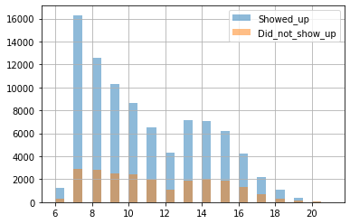

```python
df.sched_h[showed==1].hist(alpha=0.5,bins=30 ,label='Showed_up');
df.sched_h[showed==0].hist(alpha=0.5,bins=30 ,label='Did_not_show_up');
plt.legend();
```

### No patterns we need further explorations

```python
df['PatientId'].value_counts().to_frame().head(4)
```

|  | PatientId |
| --- | --- |
| 8.221459e+14 | 88 |
| 9.963767e+10 | 84 |
| 2.688613e+13 | 70 |
| 3.353478e+13 | 65 |

Many patients had more than 1 Appointment

Making new column for people that had more than 1 appointment

```python
df['again']=0
```

```python
isdup=df['PatientId'].duplicated()==True
df.loc[df['PatientId'].duplicated()==True,'again']=1
```

```python
df.head(10)
```

|  | PatientId | Gender | Age | Neighbourhood | Scholarship | Hipertension | Diabetes | Alcoholism | Handcap | SMS_received | showed | date_dif | sched_h | again |
| --- | --- | --- | --- | --- | --- | --- | --- | --- | --- | --- | --- | --- | --- | --- |
| 0 | 2.987250e+13 | F | 62 | JARDIM DA PENHA | 0 | 1 | 0 | 0 | 0 | 0 | 1 | 0 | 18 | 0 |
| 1 | 5.589978e+14 | M | 56 | JARDIM DA PENHA | 0 | 0 | 0 | 0 | 0 | 0 | 1 | 0 | 16 | 0 |
| 2 | 4.262962e+12 | F | 62 | MATA DA PRAIA | 0 | 0 | 0 | 0 | 0 | 0 | 1 | 0 | 16 | 0 |
| 3 | 8.679512e+11 | F | 8 | PONTAL DE CAMBURI | 0 | 0 | 0 | 0 | 0 | 0 | 1 | 0 | 17 | 0 |
| 4 | 8.841186e+12 | F | 56 | JARDIM DA PENHA | 0 | 1 | 1 | 0 | 0 | 0 | 1 | 0 | 16 | 0 |
| 5 | 9.598513e+13 | F | 76 | REPÚBLICA | 0 | 1 | 0 | 0 | 0 | 0 | 1 | 2 | 8 | 0 |
| 6 | 7.336882e+14 | F | 23 | GOIABEIRAS | 0 | 0 | 0 | 0 | 0 | 0 | 0 | 2 | 15 | 0 |
| 7 | 3.449833e+12 | F | 39 | GOIABEIRAS | 0 | 0 | 0 | 0 | 0 | 0 | 0 | 2 | 15 | 0 |
| 8 | 5.639473e+13 | F | 21 | ANDORINHAS | 0 | 0 | 0 | 0 | 0 | 0 | 1 | 0 | 8 | 0 |
| 9 | 7.812456e+13 | F | 19 | CONQUISTA | 0 | 0 | 0 | 0 | 0 | 0 | 1 | 2 | 12 | 0 |

let's see if there is any relation between showing up and having more than 1 appointment

```python
print("{:.1f}% of new patients showed Up".format(df[df['again']==0]['showed'].mean()*100))
print("{:.1f}% of old patients Up".format(df[df['again']==1]['showed'].mean()*100))
```

```
80.4% of new patients showed Up
79.0% of old patients Up
```

let's categories date_dif from 0 to 4 low , 5 to 14 Medium ,Bigger than 14 High

```python
df['date_dif'].describe()
```

```
count    110521.000000
mean         10.184345
std          15.255153
min           0.000000
25%           0.000000
50%           4.000000
75%          15.000000
max         179.000000
Name: date_dif, dtype: float64
```

```python
df['date_dif']=df['date_dif'].apply(lambda x:"low" if x<= 4 else ("medium" if (x > 4 and x <= 14) else "high"))
df.head()
```

|  | PatientId | Gender | Age | Neighbourhood | Scholarship | Hipertension | Diabetes | Alcoholism | Handcap | SMS_received | showed | date_dif | sched_h | again |
| --- | --- | --- | --- | --- | --- | --- | --- | --- | --- | --- | --- | --- | --- | --- |
| 0 | 2.987250e+13 | F | 62 | JARDIM DA PENHA | 0 | 1 | 0 | 0 | 0 | 0 | 1 | low | 18 | 0 |
| 1 | 5.589978e+14 | M | 56 | JARDIM DA PENHA | 0 | 0 | 0 | 0 | 0 | 0 | 1 | low | 16 | 0 |
| 2 | 4.262962e+12 | F | 62 | MATA DA PRAIA | 0 | 0 | 0 | 0 | 0 | 0 | 1 | low | 16 | 0 |
| 3 | 8.679512e+11 | F | 8 | PONTAL DE CAMBURI | 0 | 0 | 0 | 0 | 0 | 0 | 1 | low | 17 | 0 |
| 4 | 8.841186e+12 | F | 56 | JARDIM DA PENHA | 0 | 1 | 1 | 0 | 0 | 0 | 1 | low | 16 | 0 |

let's categories sched_h from 6:00 AM to 11:00 AM is morning , and from 12:00 PM to 17:00 that after noon And from 18:00 to 21:00 ( our maximum let's consider it as evening )

```python
df['sched_h'].describe()
```

```
count    110521.000000
mean         10.774522
std           3.216204
min           6.000000
25%           8.000000
50%          10.000000
75%          13.000000
max          21.000000
Name: sched_h, dtype: float64
```

```python
df['sched_h']=df['sched_h'].apply(lambda x:"morning" if x<= 11 else ("noon" if (x > 11 and x <= 17) else "evening"))
df.head()
```

|  | PatientId | Gender | Age | Neighbourhood | Scholarship | Hipertension | Diabetes | Alcoholism | Handcap | SMS_received | showed | date_dif | sched_h | again |
| --- | --- | --- | --- | --- | --- | --- | --- | --- | --- | --- | --- | --- | --- | --- |
| 0 | 2.987250e+13 | F | 62 | JARDIM DA PENHA | 0 | 1 | 0 | 0 | 0 | 0 | 1 | low | evening | 0 |
| 1 | 5.589978e+14 | M | 56 | JARDIM DA PENHA | 0 | 0 | 0 | 0 | 0 | 0 | 1 | low | noon | 0 |
| 2 | 4.262962e+12 | F | 62 | MATA DA PRAIA | 0 | 0 | 0 | 0 | 0 | 0 | 1 | low | noon | 0 |
| 3 | 8.679512e+11 | F | 8 | PONTAL DE CAMBURI | 0 | 0 | 0 | 0 | 0 | 0 | 1 | low | noon | 0 |
| 4 | 8.841186e+12 | F | 56 | JARDIM DA PENHA | 0 | 1 | 1 | 0 | 0 | 0 | 1 | low | noon | 0 |

let's group some of our categories and see if there is any patterns

```python
df.groupby(['Gender','date_dif','SMS_received','again']).aggregate({'PatientId':'count','showed':'mean'}).query('showed < 0.8')
```

| Gender | date_dif | SMS_received | again | PatientId | showed |
| --- | --- | --- | --- | --- | --- |
| F | high | 0 | 0 | 4336 | 0.649216 |
|  |  |  | 1 | 2658 | 0.620015 |
|  |  | 1 | 0 | 7012 | 0.717912 |
|  |  |  | 1 | 4540 | 0.677974 |
|  | low | 1 | 0 | 1345 | 0.776208 |
|  |  |  | 1 | 1321 | 0.784254 |
|  | medium | 0 | 0 | 3206 | 0.707424 |
|  |  |  | 1 | 3060 | 0.663725 |
|  |  | 1 | 0 | 5189 | 0.737907 |
|  |  |  | 1 | 4795 | 0.721794 |
| M | high | 0 | 0 | 2471 | 0.619183 |
|  |  |  | 1 | 1354 | 0.598966 |
|  |  | 1 | 0 | 3517 | 0.701450 |
|  |  |  | 1 | 1861 | 0.687802 |
|  | low | 1 | 0 | 750 | 0.793333 |
|  |  |  | 1 | 544 | 0.746324 |
|  | medium | 0 | 0 | 1737 | 0.690271 |
|  |  |  | 1 | 1650 | 0.692727 |
|  |  | 1 | 0 | 2582 | 0.749419 |
|  |  |  | 1 | 2026 | 0.756663 |

```python
df.groupby(['date_dif','SMS_received']).aggregate({'PatientId':'count','showed':'mean'})
```

| date_dif | SMS_received | PatientId | showed |
| --- | --- | --- | --- |
| high | 0 | 10819 | 0.628894 |
|  | 1 | 16930 | 0.700473 |
| low | 0 | 54567 | 0.899152 |
|  | 1 | 3960 | 0.778030 |
| medium | 0 | 9653 | 0.687973 |
|  | 1 | 14592 | 0.737253 |

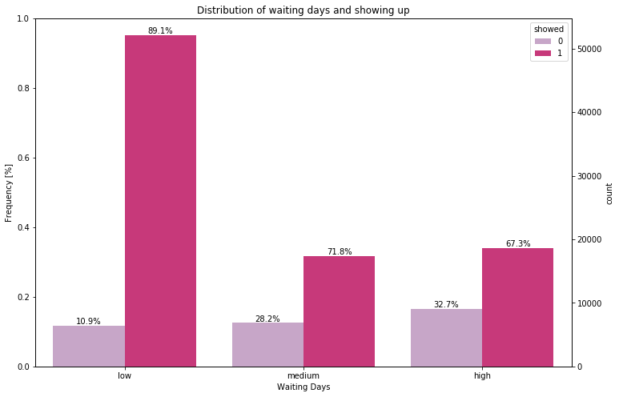

```python
plt.figure(figsize=(12,8))
ax = sns.countplot(x='date_dif',hue='showed',data=df,palette="PuRd");
lcount = len(df[df['date_dif']=='low'])
mcount=len(df[df['date_dif']=='medium'])
hcount=len(df[df['date_dif']=='high'])
ax.axes.set_title("Distribution of waiting days and showing up");
ax.axes.set_xlabel("Waiting Days");

# Make twin axis
ax2=ax.twinx()

# Switch so count axis is on right, frequency on left
ax2.yaxis.tick_left()
ax.yaxis.tick_right()

# Also switch the labels over
ax.yaxis.set_label_position('right')
ax2.yaxis.set_label_position('left')

ax2.set_ylabel('Frequency [%]')

for i,p in enumerate(ax.patches):
    x=p.get_bbox().get_points()[:,0]
    y=p.get_bbox().get_points()[1,1]
    if i in [0,3]:
        ax.annotate('{:.1f}%'.format(100.*(y/lcount)), (x.mean(), y),
            ha='center', va='bottom')
    elif i in [1,4]:
        ax.annotate('{:.1f}%'.format(100.*(y/mcount)), (x.mean(), y),
            ha='center', va='bottom')
    else:
        ax.annotate('{:.1f}%'.format(100.*(y/hcount)), (x.mean(), y),
            ha='center', va='bottom')
```

## Conclusions

we were able to extract valuabe patterns from visualizations after grouping them only

people that waited to long and this was their first Appointment 32% of them missed thier appointments

the gender factor didn’t play any role in determining wether the patient will show up or no cause the perctanges were nearly equal

there is no feature u can say that this feature can determine wether the patient will show up or no

#### Limitations

there is insufficient data cause the data sample size is not big enough to let us predict the actions of the whole population based on this data set

this type of data set is not valid for causal inference it is only valid for descriptive statistics

```python
from subprocess import call
call(['python', '-m', 'nbconvert', 'Investigate_a_Dataset.ipynb'])
```

```
0
```